# Home-work 1, data 608, Fall 2018

Mehdi M Khan

**Principles of Data Visualization and Introduction to ggplot2**

data about the 5,000 fastest growing companies in the US, as compiled by Inc. magazine.

#### load the data:

```r
inc <- read.csv("https://raw.githubusercontent.com/kmehdi2017/data608/master/hw_module1/Data/inc5000_data.csv", header= TRUE)
```

#### preview data:

```r
head(inc)
```

```
##   Rank                         Name Growth_Rate   Revenue
## 1    1                         Fuhu      421.48 1.179e+08
## 2    2        FederalConference.com      248.31 4.960e+07
## 3    3                The HCI Group      245.45 2.550e+07
## 4    4                      Bridger      233.08 1.900e+09
## 5    5                       DataXu      213.37 8.700e+07
## 6    6 MileStone Community Builders      179.38 4.570e+07
##                       Industry Employees         City State
## 1 Consumer Products & Services       104   El Segundo    CA
## 2          Government Services        51     Dumfries    VA
## 3                       Health       132 Jacksonville    FL
## 4                       Energy        50      Addison    TX
## 5      Advertising & Marketing       220       Boston    MA
## 6                  Real Estate        63       Austin    TX
```

#### descriptive statistics:

```r
summary(inc)
```

```
##       Rank                          Name       Growth_Rate
##  Min.   :   1   (Add)ventures         :   1   Min.   :  0.340
##  1st Qu.:1252   @Properties           :   1   1st Qu.:  0.770
##  Median :2502   1-Stop Translation USA:   1   Median :  1.420
##  Mean   :2502   110 Consulting        :   1   Mean   :  4.612
##  3rd Qu.:3751   11thStreetCoffee.com  :   1   3rd Qu.:  3.290
##  Max.   :5000   123 Exteriors         :   1   Max.   :421.480
##                 (Other)               :4995
##     Revenue                                  Industry      Employees
##  Min.   :2.000e+06   IT Services                 : 733   Min.   :    1.0
##  1st Qu.:5.100e+06   Business Products & Services: 482   1st Qu.:   25.0
##  Median :1.090e+07   Advertising & Marketing     : 471   Median :   53.0
##  Mean   :4.822e+07   Health                      : 355   Mean   :  232.7
##  3rd Qu.:2.860e+07   Software                    : 342   3rd Qu.:  132.0
##  Max.   :1.010e+10   Financial Services          : 260   Max.   :66803.0
##                      (Other)                     :2358   NA's   :12
##             City          State
##  New York     : 160   CA     : 701
##  Chicago      :  90   TX     : 387
##  Austin       :  88   NY     : 311
##  Houston      :  76   VA     : 283
##  San Francisco:  75   FL     : 282
##  Atlanta      :  74   IL     : 273
##  (Other)      :4438   (Other):2764
```

#### some more relevant non-visual exploratory information about the data:

```r
# Insert your code here, create more chunks as necessary

options(scipen=999) # to avoid scientific notations

# Getting more descriptive statistics of the data
suppressWarnings(suppressMessages(library(psych)))
describe(inc)
```

```
##             vars    n        mean           sd      median     trimmed
## Rank           1 5001     2501.64      1443.51     2502.00     2501.73
## Name*          2 5001     2501.00      1443.81     2501.00     2501.00
## Growth_Rate    3 5001        4.61        14.12        1.42        2.14
## Revenue        4 5001 48222535.49 240542281.14 10900000.00 17334966.26
## Industry*      5 5001       12.10         7.33       13.00       12.05
## Employees      6 4989      232.72      1353.13       53.00       81.78
## City*          7 5001      732.00       441.12      761.00      731.74
## State*         8 5001       24.80        15.64       23.00       24.44
##                     mad        min            max          range  skew
## Rank            1853.25       1.00        5000.00        4999.00  0.00
## Name*           1853.25       1.00        5001.00        5000.00  0.00
## Growth_Rate        1.22       0.34         421.48         421.14 12.55
## Revenue     10674720.00 2000000.00 10100000000.00 10098000000.00 22.17
## Industry*          8.90       1.00          25.00          24.00 -0.10
## Employees         53.37       1.00       66803.00       66802.00 29.81
## City*            604.90       1.00        1519.00        1518.00 -0.04
## State*            19.27       1.00          52.00          51.00  0.12
##             kurtosis         se
## Rank           -1.20      20.41
## Name*          -1.20      20.42
## Growth_Rate   242.34       0.20
## Revenue       722.66 3401441.44
## Industry*      -1.18       0.10
## Employees    1268.67      19.16
## City*          -1.26       6.24
## State*         -1.46       0.22
```

```r
# information about data types, zeros,  missing values, unique values
suppressWarnings(suppressMessages(library(funModeling)))
df_status(inc)
```

```
##      variable q_zeros p_zeros q_na p_na q_inf p_inf    type unique
## 1        Rank       0       0    0 0.00     0     0 integer   4999
## 2        Name       0       0    0 0.00     0     0  factor   5001
## 3 Growth_Rate       0       0    0 0.00     0     0 numeric   1147
## 4     Revenue       0       0    0 0.00     0     0 numeric   1069
## 5    Industry       0       0    0 0.00     0     0  factor     25
## 6   Employees       0       0   12 0.24     0     0 integer    691
## 7        City       0       0    0 0.00     0     0  factor   1519
## 8       State       0       0    0 0.00     0     0  factor     52
```

## Question 1

Create a graph that shows the distribution of companies in the dataset by State (ie how many are in each state). There are a lot of States, so consider which axis you should use. This visualization is ultimately going to be consumed on a ‘portrait’ oriented screen (ie taller than wide), which should further guide your layout choices.

```r
# load libraries
suppressMessages(suppressWarnings(library(ggplot2)))
suppressMessages(suppressWarnings(library(dplyr)))
suppressMessages(suppressWarnings(library(plyr)))
suppressMessages(suppressWarnings(library(grid)))
```

### Answer (plot 1)

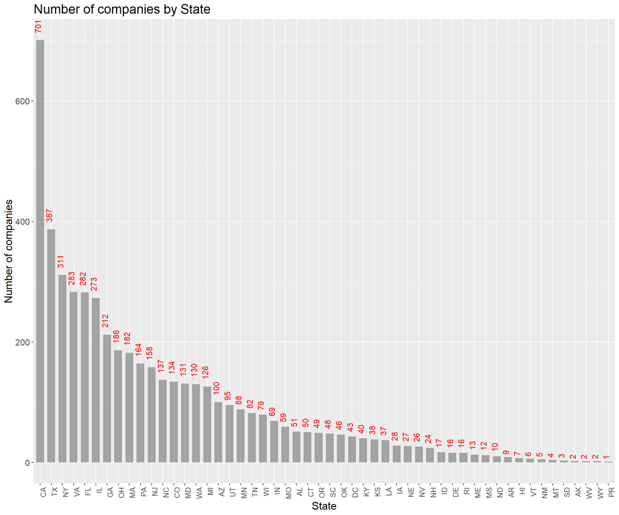

```r
inc_state <- ddply(inc,"State",summarise, "company_count"=length(Name))

p <- ggplot(inc_state,aes(x=reorder(State,-company_count),y=company_count))
p <- p + geom_bar(stat = "identity", alpha=.5, width=0.7)
p <- p + labs(title = "Number of companies by State", x= "State",y = "Number of companies")
p <- p + theme(plot.title = element_text(size=18),
               axis.text.x = element_text(angle=90, hjust = 1, size = 10 ),
               axis.text.y = element_text(size = 12 ),
               axis.title.x = element_text(size = 15 ),
               axis.title.y = element_text(size = 15 ))

p <- p + geom_text( aes(label=company_count),vjust=.10, angle=90, hjust=-.5, col="red", size=4)
p
```

## Quesiton 2

Lets dig in on the state with the 3rd most companies in the data set. Imagine you work for the state and are interested in how many people are employed by companies in different industries. Create a plot that shows the average and/or median employment by industry for companies in this state (only use cases with full data, use R’s `complete.cases()` function.) In addition to this, your graph should show how variable the ranges are, and you should deal with outliers.

### answer (Plot 2)

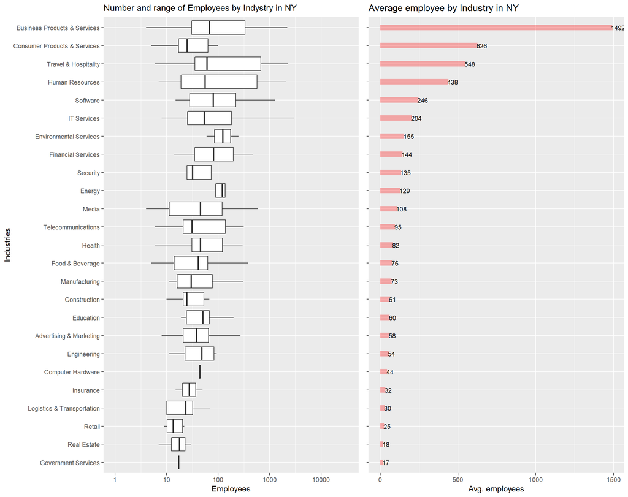

```r
# Answer Question 2 here

# The above plot (plot 1) shows 'NY' is with the 3rd most companies in the data set
inc2 <- inc[complete.cases(inc),]
inc2 <- inc2[which (inc2$State =='NY'),]



p1 <- ggplot(inc2,aes(reorder(Industry,Employees,mean),Employees))  + geom_boxplot(outlier.shape = NA, show.legend=F)+ labs(title="Number and range of Employees by Indystry in NY",x="Industries") + coord_flip() +
    scale_y_continuous(
        trans = "log10"
    ) + theme(plot.title = element_text(size = 12) )

mean_fun <- function(x){
  return(data.frame(y = mean(x), label = paste0("mean = ",round(mean(x),1))))
}


p2 <- ggplot(inc2, aes(reorder(Industry,Employees,mean),Employees) )+ stat_summary(fun.y = mean,geom = "bar", width=.3,fill="red", alpha=.3) + stat_summary(aes(label=round(..y..,0)),fun.y = mean,geom = "text", size=3, hjust=.1 ) + coord_flip()+labs(title="Average employee by Industry in NY", y="Avg. employees")+theme(axis.text.y=element_blank(),axis.title.y=element_blank())

grid.newpage()
grid.draw(cbind(ggplotGrob(p1),ggplotGrob(p2),size="last"))
```

## Question 3

Now imagine you work for an investor and want to see which industries generate the most revenue per employee. Create a chart that makes this information clear. Once again, the distribution per industry should be shown.

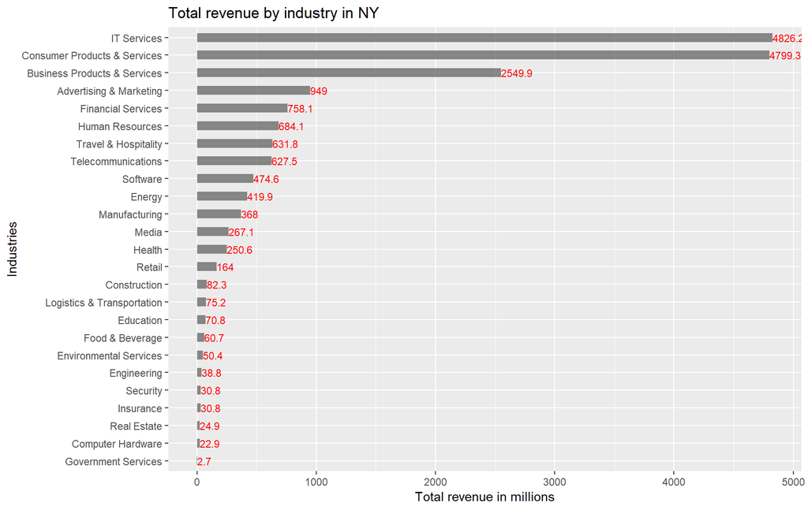

```r
# Answer Question 3 here
emp_rev <- ddply(inc2,"Industry",summarise,"Total_revenue" = sum(Revenue))
ggplot(emp_rev,aes(reorder(Industry,Total_revenue),Total_revenue/1000000))+geom_bar(stat = "identity", width = .5, alpha=.7)+coord_flip() + geom_text(aes(label=Total_revenue/1000000), size=3, colour="red",hjust=0) + labs(title="Total revenue by industry in NY", x= "Industries", y = "Total revenue in millions")
```